# Basic Visualization in R

# Part 1: Load Software, Interview Data

Load Data

```r
#At Home: See Appendix to load data at home from Internet

SF <- rio::import("https://docs.google.com/spreadsheets/d/1-nkosLJKkfeLSl-UG82DDyiEw5-62kX2alS6ICG9iuk/edit#gid=552005485", sheet = "SF Police_Department_Calls_for_")
```

– **Interview the Data**

```r
head(SF)
```

```
##    Crime Id Original Crime Type Name Report Date Call Date Offense Date
## 1 190040497                      919    1/4/2019  1/4/2019     1/4/2019
## 2 190200644       Homeless Complaint   1/20/2019 1/20/2019    1/20/2019
## 3 190213959       Homeless Complaint   1/21/2019 1/21/2019    1/21/2019
## 4 190271011                      915   1/27/2019 1/27/2019    1/27/2019
## 5 190141952       Homeless Complaint   1/14/2019 1/14/2019    1/14/2019
## 6 190020699       Homeless Complaint    1/2/2019  1/2/2019     1/2/2019
##   Call Time Call Date Time Disposition                 Address          City
## 1      6:58    1/4/19 6:58         HAN   400 Block Of Jones St San Francisco
## 2      6:19   1/20/19 6:19         HAN          8th And Market
## 3     22:42  1/21/19 22:42         ADV      Mission St/24th St San Francisco
## 4      9:28   1/27/19 9:28         HAN      Alabama St/23rd St San Francisco
## 5     13:20  1/14/19 13:20         HAN     Newcomb Av/quint St San Francisco
## 6      8:19    1/2/19 8:19         HAN 700 Block Of Funston Av San Francisco
##   State Agency Id    Address Type Common Location
## 1    CA         1 Premise Address
## 2    CA         1    Geo-Override
## 3    CA         1    Intersection
## 4    CA         1    Intersection
## 5    CA         1    Intersection
## 6    CA         1 Premise Address
```

```r
#view(SF)
```

– **Really Interview the Data** How big are you? Rows? Columns? List of column names?

```r
nrow(SF)
```

```
## [1] 157237
```

```r
ncol(SF)
```

```
## [1] 14
```

```r
glimpse(SF)
```

```
## Rows: 157,237
## Columns: 14
## $ `Crime Id`                 <int> 190040497, 190200644, 190213959, 190271011,…
## $ `Original Crime Type Name` <chr> "919", "Homeless Complaint", "Homeless Comp…
## $ `Report Date`              <chr> "1/4/2019", "1/20/2019", "1/21/2019", "1/27…
## $ `Call Date`                <chr> "1/4/2019", "1/20/2019", "1/21/2019", "1/27…
## $ `Offense Date`             <chr> "1/4/2019", "1/20/2019", "1/21/2019", "1/27…
## $ `Call Time`                <chr> "6:58", "6:19", "22:42", "9:28", "13:20", "…
## $ `Call Date Time`           <chr> "1/4/19 6:58", "1/20/19 6:19", "1/21/19 22:…
## $ Disposition                <chr> "HAN", "HAN", "ADV", "HAN", "HAN", "HAN", "…
## $ Address                    <chr> "400 Block Of Jones St", "8th And Market", …
## $ City                       <chr> "San Francisco", "", "San Francisco", "San …
## $ State                      <chr> "CA", "CA", "CA", "CA", "CA", "CA", "CA", "…
## $ `Agency Id`                <int> 1, 1, 1, 1, 1, 1, 1, 1, 1, 1, 1, 1, 1, 1, 1…
## $ `Address Type`             <chr> "Premise Address", "Geo-Override", "Interse…
## $ `Common Location`          <chr> "", "", "", "", "", "", "Jose Coronado Plgd…
```

- **Clean column names, Process dates**

```r
#This cleans column names
SF <- janitor::clean_names(SF)
#This processes dates for analysis
SF$call_date2 <- mdy(SF$call_date)
#This creates a new column for year
SF$year <- year(SF$call_date2)
```

– **Sort by Date**

```
We're using a weirdo command called a 'pipe' - %>% - that joins
lines of code. In the example below, the SF table is filtered in descending order and the results are dumped into a new file called SF1.
```

```r
#descending order
SF1 <- SF %>%
arrange(desc(report_date))

head(SF1)
```

```
##    crime_id original_crime_type_name report_date call_date offense_date
## 1 192522142       Homeless Complaint    9/9/2019  9/9/2019     9/9/2019
## 2 192520397       Homeless Complaint    9/9/2019  9/9/2019     9/9/2019
## 3 192520401       Homeless Complaint    9/9/2019  9/9/2019     9/9/2019
## 4 192520407       Homeless Complaint    9/9/2019  9/9/2019     9/9/2019
## 5 192520421       Homeless Complaint    9/9/2019  9/9/2019     9/9/2019
## 6 192520425       Homeless Complaint    9/9/2019  9/9/2019     9/9/2019
##   call_time call_date_time disposition                  address          city
## 1     13:14   9/9/19 13:14         UTL              1023 Myrtle
## 2      5:14    9/9/19 5:14         HAN 2000 Block Of Lombard St San Francisco
## 3      5:17    9/9/19 5:17         HAN        19th St/folsom St San Francisco
## 4      5:25    9/9/19 5:25         HAN      Harrison St/18th St San Francisco
## 5      5:33    9/9/19 5:33         ADV         17th St/treat Av San Francisco
## 6      5:34    9/9/19 5:34         HAN 1000 Block Of Mission St San Francisco
##   state agency_id    address_type common_location call_date2 year
## 1    CA         1    Geo-Override                 2019-09-09 2019
## 2    CA         1 Premise Address                 2019-09-09 2019
## 3    CA         1    Intersection                 2019-09-09 2019
## 4    CA         1    Intersection                 2019-09-09 2019
## 5    CA         1    Intersection                 2019-09-09 2019
## 6    CA         1 Premise Address                 2019-09-09 2019
```

```r
#ascending order
SF1 <- SF %>% arrange(report_date)
head(SF1)
```

```
##    crime_id original_crime_type_name report_date call_date offense_date
## 1 170010123       Homeless Complaint    1/1/2017  1/1/2017     1/1/2017
## 2 170010512       Homeless Complaint    1/1/2017  1/1/2017     1/1/2017
## 3 170010590       Homeless Complaint    1/1/2017  1/1/2017     1/1/2017
## 4 170011131       Homeless Complaint    1/1/2017  1/1/2017     1/1/2017
## 5 170011195       Homeless Complaint    1/1/2017  1/1/2017     1/1/2017
## 6 170011234       Homeless Complaint    1/1/2017  1/1/2017     1/1/2017
##   call_time call_date_time disposition                  address          city
## 1      0:21    1/1/17 0:21         HAN    500 Block Of Berry St San Francisco
## 2      1:49    1/1/17 1:49         ADV       Harrison St/9th St San Francisco
## 3      2:11    1/1/17 2:11         ADV    1100 Block Of Bush St San Francisco
## 4      5:42    1/1/17 5:42         HAN        Folsom St/dore St San Francisco
## 5      6:16    1/1/17 6:16         HAN    300 Block Of Ellis St San Francisco
## 6      6:47    1/1/17 6:47         GOA California St/battery St San Francisco
##   state agency_id    address_type common_location call_date2 year
## 1    CA         1 Premise Address                 2017-01-01 2017
## 2    CA         1    Intersection                 2017-01-01 2017
## 3    CA         1 Premise Address                 2017-01-01 2017
## 4    CA         1    Intersection                 2017-01-01 2017
## 5    CA         1 Premise Address                 2017-01-01 2017
## 6    CA         1    Intersection                 2017-01-01 2017
```

- **311 Calls by Year**

```r
Years <- SF %>%
  count(year) %>%
  group_by(year) %>%
  arrange(desc(year))
head(Years)
```

```
## # A tibble: 4 × 2
## # Groups:   year [4]
##    year     n
##   <dbl> <int>
## 1  2019 33855
## 2  2018 36057
## 3  2017 49523
## 4  2016 37802
```

## Basic ggplot

– **Graph Years using ggplot**

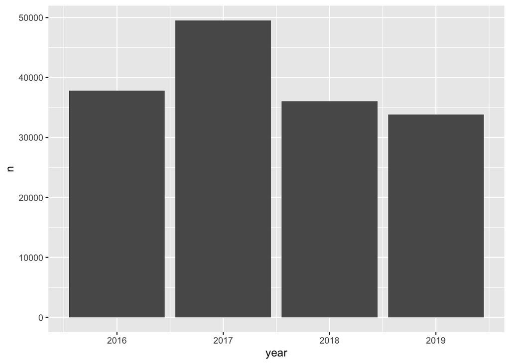

```r
ggplot(data=Years) +
  geom_col(mapping=aes(x=year, y=n))
```

– **That’s ugly. Add some color: fill=**

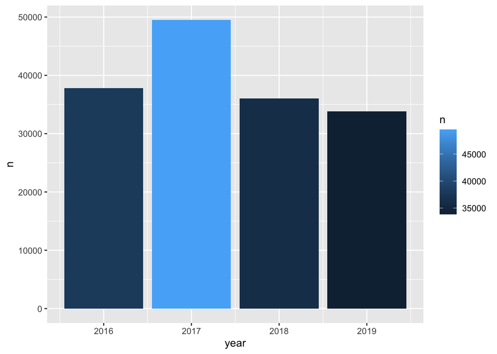

```r
ggplot(data=Years) +
  geom_col(mapping=aes(x=year, y=n, fill=n))
```

– **Ditch the legend**

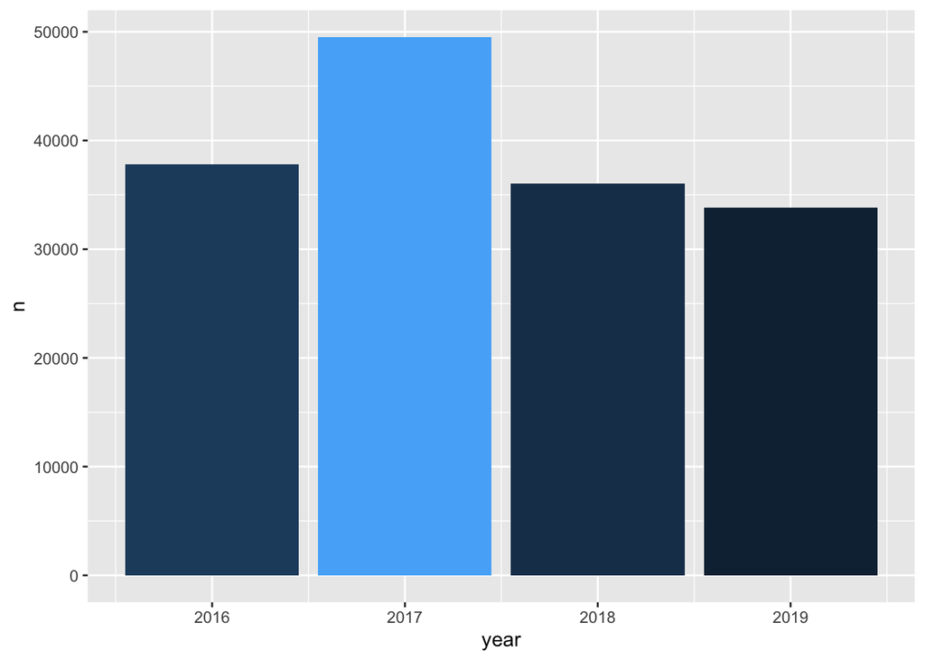

```r
ggplot(Years,aes(x = year, y = n,
             fill = n)) +
  geom_col(position = "dodge") +
  theme(legend.position = "none")
```

– **Add Headlines, Annotations and Credits**

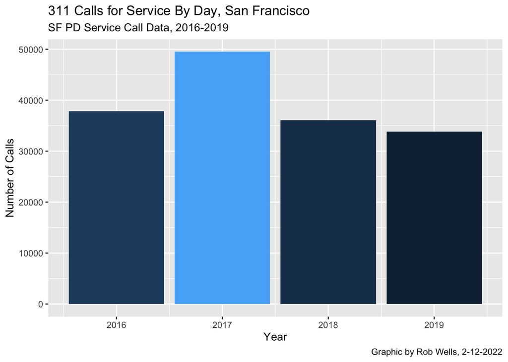

```r
ggplot(Years,aes(x = year, y = n,
             fill = n)) +
  geom_col(position = "dodge") +
  theme(legend.position = "none") +
#This is your title sequence
  labs(title = "311 Calls for Service By Day, San Francisco",
       subtitle = "SF PD Service Call Data, 2016-2019",
       caption = "Graphic by Rob Wells, 2-12-2022",
       y="Number of Calls",
       x="Year")
```

– **Filter a dataset, build a chart in one code block**

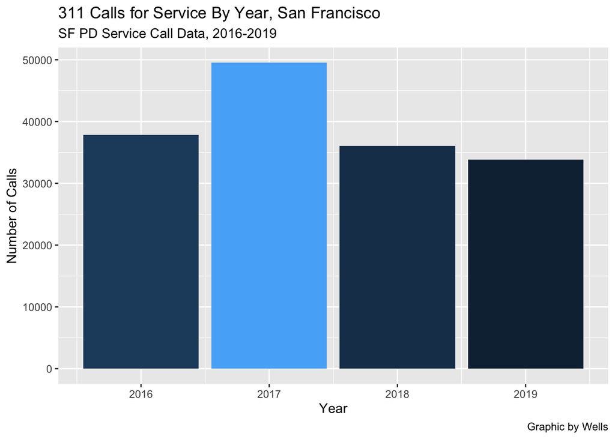

```r
#Copy section of code from above...
SF %>%
   count(year) %>%
   group_by(year) %>%
#Sandwich it onto a simple ggplot
  ggplot(aes(x = year, y = n, fill = n)) +
  geom_col(position = "dodge") +
  theme(legend.position = "none") +
  labs(title = "311 Calls for Service By Year, San Francisco",
       subtitle = "SF PD Service Call Data, 2016-2019",
       caption = "Graphic by Wells",
       y="Number of Calls",
       x="Year")
```

- **Which Day Had the Most 311 Calls?** Using count to tabulate calls by day

```r
Days <- SF %>%
  count(call_date2) %>%
  arrange(desc(n))

head(Days)
```

```
##   call_date2   n
## 1 2019-08-15 232
## 2 2018-04-19 221
## 3 2016-04-18 218
## 4 2018-03-28 217
## 5 2018-05-08 217
## 6 2017-04-19 215
```

– **Chart Calls by Day**

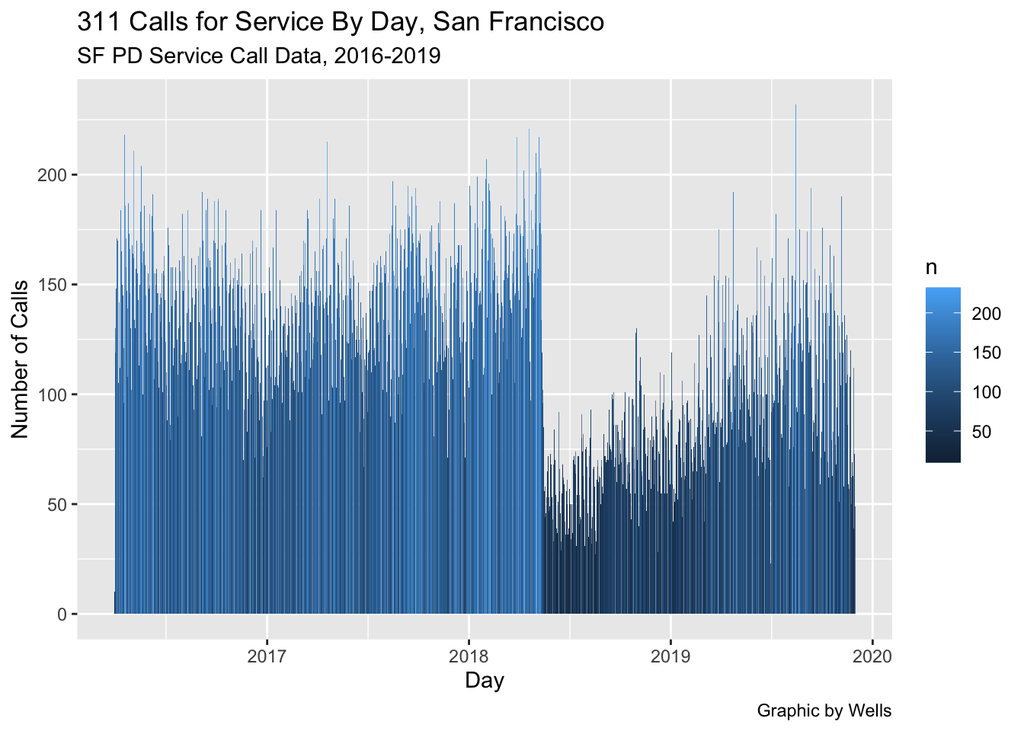

```r
#Adapting code from above...
SF %>%
  count(call_date2) %>%
#Sandwich it onto a simple ggplot
  ggplot(aes(x = call_date2, y = n, fill = n)) +
  geom_bar(stat = "identity") +
  labs(title = "311 Calls for Service By Day, San Francisco",
       subtitle = "SF PD Service Call Data, 2016-2019",
       caption = "Graphic by Wells",
       y="Number of Calls",
       x="Day")
```

- **Interviewing: Types of Crimes**

```r
SF1 <- SF %>% count(original_crime_type_name) %>%
    arrange(desc(n))
head(SF1)
```

```
##   original_crime_type_name      n
## 1       Homeless Complaint 142780
## 2                      915   9283
## 3                      919   2879
## 4              915 Sleeper    290
## 5                      920    226
## 6                  915/919    161
```

```r
#view(SF1)
```

- **Interviewing: Actions Taken**

```r
Action <- SF %>%
  count(disposition) %>%
  arrange(desc(n))
head(Action)
```

```
##    disposition     n
## 1          HAN 51064
## 2          ADV 49823
## 3          GOA 31951
## 4          CIT  6053
## 5          UTL  4994
## 6 Not recorded  4339
```

```r
#view(Action)
```

# Part 2: Analysis

- **Summary**: Using the summary() function, describe the minimum, maximum, median and mean of calls in the Days table

```r
summary(Days)
```

```
##    call_date2               n
##  Min.   :2016-03-31   Min.   : 10.0
##  1st Qu.:2017-02-28   1st Qu.: 86.0
##  Median :2018-01-29   Median :119.0
##  Mean   :2018-01-29   Mean   :117.3
##  3rd Qu.:2018-12-30   3rd Qu.:148.0
##  Max.   :2019-11-30   Max.   :232.0
```

Between March 31, 2016 and Nov. 30, 2019, San Francisco residents placed **an average 117 calls** to police complaining about homeless people.

- **Question**: Identify the day with the most calls?

```r
#Group_by gathers and allows tabulation of all days
Days %>%
  group_by(call_date2) %>%
  filter(n == max(n))
```

```
## # A tibble: 1,340 × 2
## # Groups:   call_date2 [1,340]
##    call_date2     n
##    <date>     <int>
##  1 2019-08-15   232
##  2 2018-04-19   221
##  3 2016-04-18   218
##  4 2018-03-28   217
##  5 2018-05-08   217
##  6 2017-04-19   215
##  7 2016-05-04   211
##  8 2018-05-02   210
##  9 2018-02-02   207
## 10 2016-05-18   204
## # ℹ 1,330 more rows
```

```r
#See what happens without group_by - only the top value is computed, not the aggregation of the component parts
Days %>%
  # group_by(call_date2) %>%
  filter(n == max(n))
```

```
##   call_date2   n
## 1 2019-08-15 232
```

– **Breaking Down Group_By**

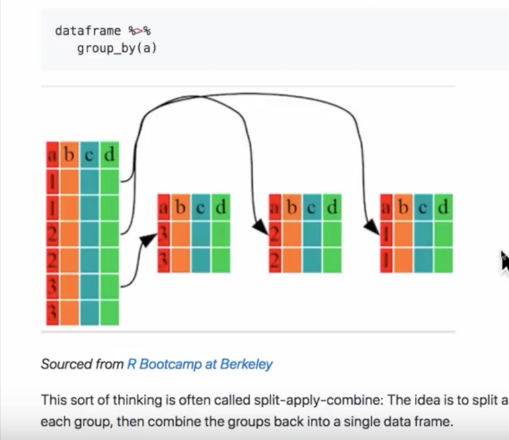

– **Many thanks**, Ben Stenhaug: https://www.youtube.com/watch?v=6xbGZDUu5W4

- **Question**: Identify the top 5 days with the most calls?

```r
Days %>%
   slice_max(n, n = 5)
```

```
##   call_date2   n
## 1 2019-08-15 232
## 2 2018-04-19 221
## 3 2016-04-18 218
## 4 2018-03-28 217
## 5 2018-05-08 217
```

```r
#slice_max to the rescue: https://dplyr.tidyverse.org/reference/slice.html

#Or
#Filter by the value
# Days %>%
#   filter(n == 232)
```

- **Question**: Identify the top 5 days with the fewest calls?

```r
Days %>%
   slice_min(n, n = 5)
```

```
##   call_date2  n
## 1 2016-03-31 10
## 2 2019-06-30 23
## 3 2018-06-09 25
## 4 2018-08-18 27
## 5 2019-01-06 27
```

```r
#Or
#Filter by the value
# Days %>%
#   filter(n == 10)
```

– **Tabulate types of events**: What are the top five complaints in this data and provide the number of complaints

```r
#Start with same code as above
Types <- SF %>% count(original_crime_type_name) %>%
  slice_max(n, n=5)
Types
```

```
##   original_crime_type_name      n
## 1       Homeless Complaint 142780
## 2                      915   9283
## 3                      919   2879
## 4              915 Sleeper    290
## 5                      920    226
```

– **Export to spreadsheet**

```r
write.csv(Days,"Days.csv")
```

# Part 3: Visualization

- **Question**: What were the common days for arrests?
- **Task: Tabulate complaints by day of the week**

https://github.com/profrobwells/Data-Analysis-Class-Jour-405v-5003/blob/master/Readings/dealing-with-dates.pdf

```r
SF <- SF %>%
  mutate(weekday = wday(call_date2, label=TRUE, abbr=FALSE))
```

```r
SF %>%
  select(weekday, crime_id, disposition) %>%
  filter(grepl("ARR", disposition)) %>%
  count(weekday)
```

```
##     weekday  n
## 1    Sunday 47
## 2    Monday 63
## 3   Tuesday 79
## 4 Wednesday 77
## 5  Thursday 74
## 6    Friday 56
## 7  Saturday 45
```

```r
#grepl, your find function: searches for matches of a string, returns true or false. "grep logical"
```

Make an ugly bubble chart

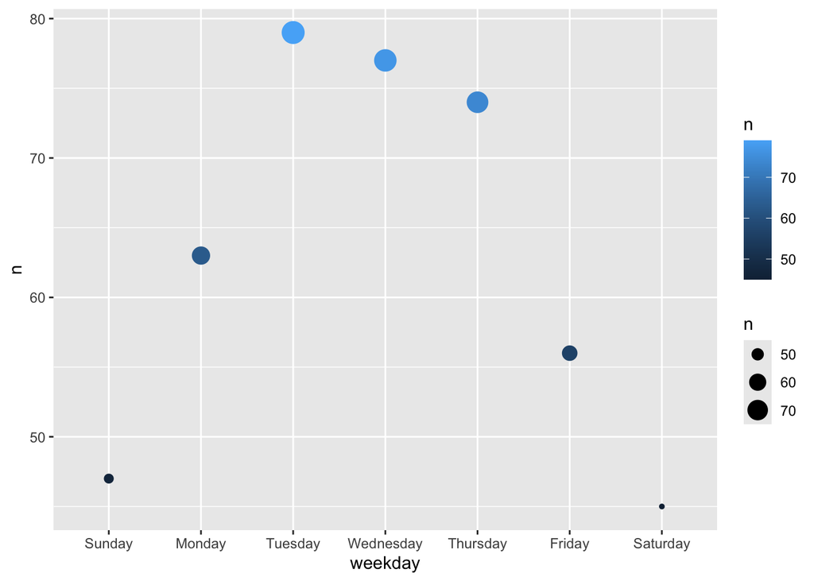

```r
  #using the code above
SF %>%
  select(weekday, crime_id, disposition) %>%
  filter(grepl("ARR", disposition)) %>%
  count(weekday) %>%

#and sandwich onto a graphic
  ggplot(aes(x = weekday, y = n)) +
  geom_point(aes(size = n, color = n))
```

– **Clean up bubble chart**

```
We add y-axis label, headline & ditch the legend
```

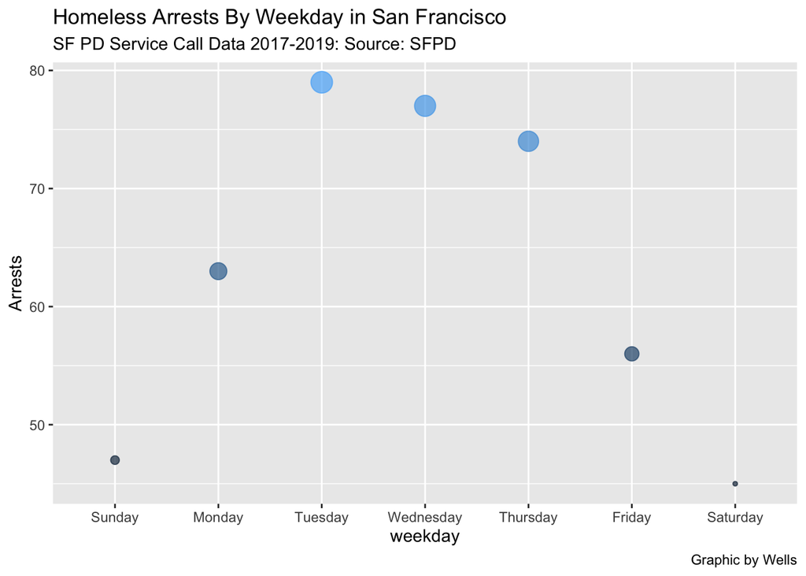

```r
  #using the code above
SF %>%
  select(weekday, crime_id, disposition) %>%
  filter(grepl("ARR", disposition)) %>%
  count(weekday) %>%
#and sandwiching onto a graphic
  ggplot(aes(x = weekday, y = n)) +
  ylab("Arrests") +
  geom_point(aes(size = n, color = n), alpha = 0.7, show.legend = FALSE) +
  labs(title = "Homeless Arrests By Weekday in San Francisco",
       subtitle = "SF PD Service Call Data 2017-2019: Source: SFPD",
       caption = "Graphic by Wells")
```

– **Pretty Bubble Chart**

```
Scaled y axis: scale_y_continuous
Bumped up bubble size: scale_size_area
saved chart to object: bubble
```

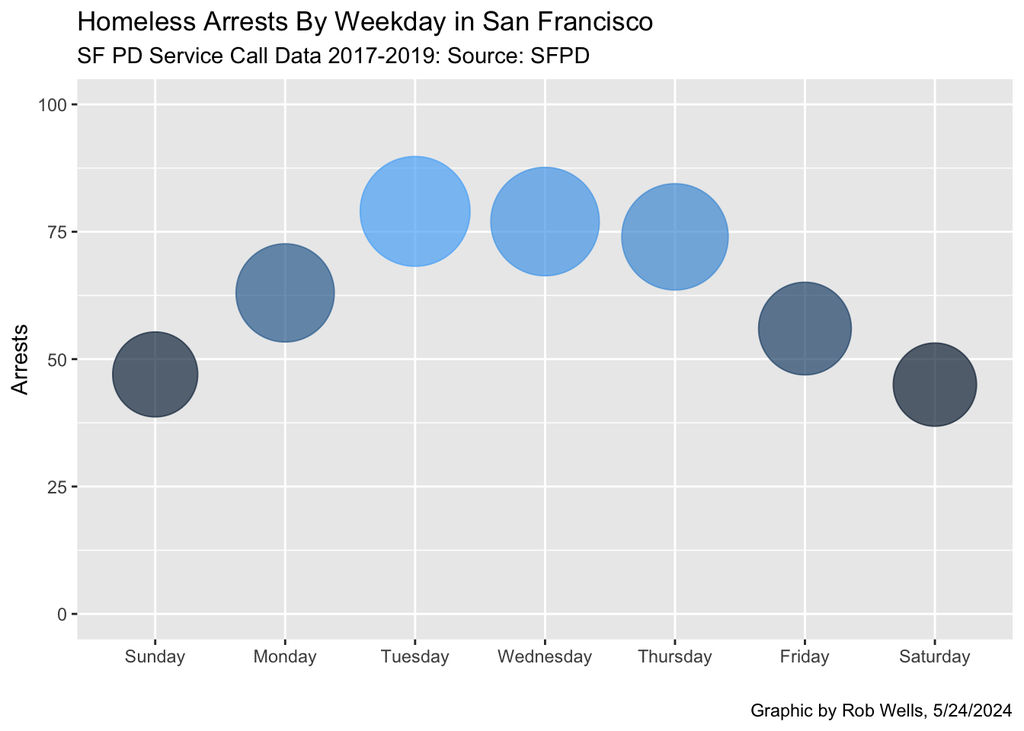

```r
  #using the code above
bubble <- SF %>%
  select(weekday, crime_id, disposition) %>%
  filter(grepl("ARR", disposition)) %>%
  count(weekday) %>%
#and sandwiching onto a graphic
  ggplot(aes(x = weekday, y = n)) +
  ylab("Arrests") +
  xlab("") +
  geom_point(aes(size = n, color = n), alpha = 0.7, show.legend = FALSE) +
  scale_size_area(guide = "none", max_size = 25) +
  scale_y_continuous(limits=c(0, 100)) +
  labs(title = "Homeless Arrests By Weekday in San Francisco",
       subtitle = "SF PD Service Call Data 2017-2019: Source: SFPD",
       caption = "Graphic by Rob Wells, 5/24/2024")
bubble
```

– **Export to Hi Res File**

```r
ggsave("bubble.png",device = "png",width=9,height=6, dpi=800)
```

# –30–